# Effets des Conflits Armés sur la Mortalité Infantile due à la Pneumonie et Interactions avec les Facteurs Économiques

Erreur de segmentation

2024-03-24

**Membre du groupe :**

- BOUGUESSA Nour
- KADDOUR Mohamed
- SBARTAI Achraf
- BENAMMAR Mahmoud

**Table de matière :**

- Introduction
- Extraction et nettoyage des données
- Distributions du GPI et du PIB
- (GPI et PIB) vs Mortalité
- Visualisation de taux de mortalité par catégorie [2008-2019]
- Visualisation de l’impact des conflits sur le PIB par habitant ET l’effet combiné sur le taux de mortalité [2008-2019]
- La matrice de corrélation
- Conclusion : Existe-il d’autres facteurs
- Sources

**Introduction**

Cette étude examine l’impact des conflits armés sur le taux de mortalité infantile par pneumonie et explore comment les conditions économiques modulent cet effet. Les conflits armés sont une source majeure d’instabilité sociale et économique, ayant un impact profond sur la santé publique. La pneumonie, en tant que principale cause de mortalité parmi les enfants de moins de 5 ans, sert d’indicateur critique pour évaluer l’effet des conflits sur la santé infantile. En outre, cette analyse considère le PIB par habitant comme un indicateur des conditions économiques, pour évaluer son rôle dans la relation entre les conflits et la mortalité due à la pneumonie. Méthodologie Nous avons utilisé un ensemble de données contenant des informations sur le taux de mortalité infantile par pneumonie, le Global Peace Index (GPI) comme mesure de l’intensité des conflits, le PIB par habitant et la taille de la population. Des analyses statistiques, y compris la corrélation de Pearson, des modèles de régression linéaire, et des visualisations graphiques, ont été employées pour explorer les relations entre ces variables.

**Extraction et nettoyage des données**

Nous avons utilisé un ensemble de données contenant des informations sur le taux de mortalité infantile par pneumonie, le Global Peace Index (GPI) comme mesure de l’intensité des conflits, le PIB par habitant et la taille de la population.

Le nettoyage des données inclut la sélection et le renommage de colonnes spécifiques, la fusion de plusieurs ensembles de données, la conversion de types de données, le traitement des valeurs manquantes et la création de nouvelles variables pour l’analyse, comme le taux de mortalité ajusté.

**Distributions du GPI et du PIB**

Après le nettoyage des données, l’analyse peut se concentrer sur l’interprétation des distributions du GPI et du PIB. -Pour le GPI : nous pouvons examiner la tendance centrale et la dispersion pour évaluer la stabilité globale. Des GPI élevés indiquent moins de paix, potentiellement augmentant le taux de la mortalité infantile par pneumonie. -Pour le PIB : nous recherchons des corrélations avec taux de mortalité infantile par pneumonie, en supposant que des PIB plus élevés correspondent à de meilleurs soins de santé et à des taux de survie plus élevés.

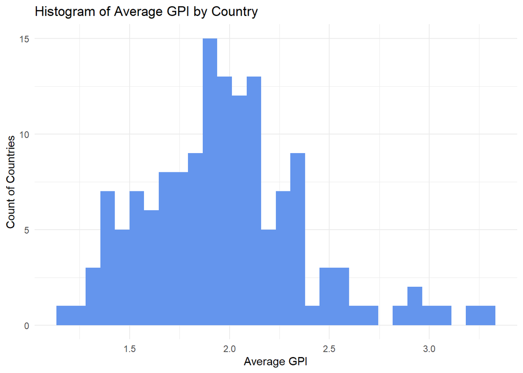

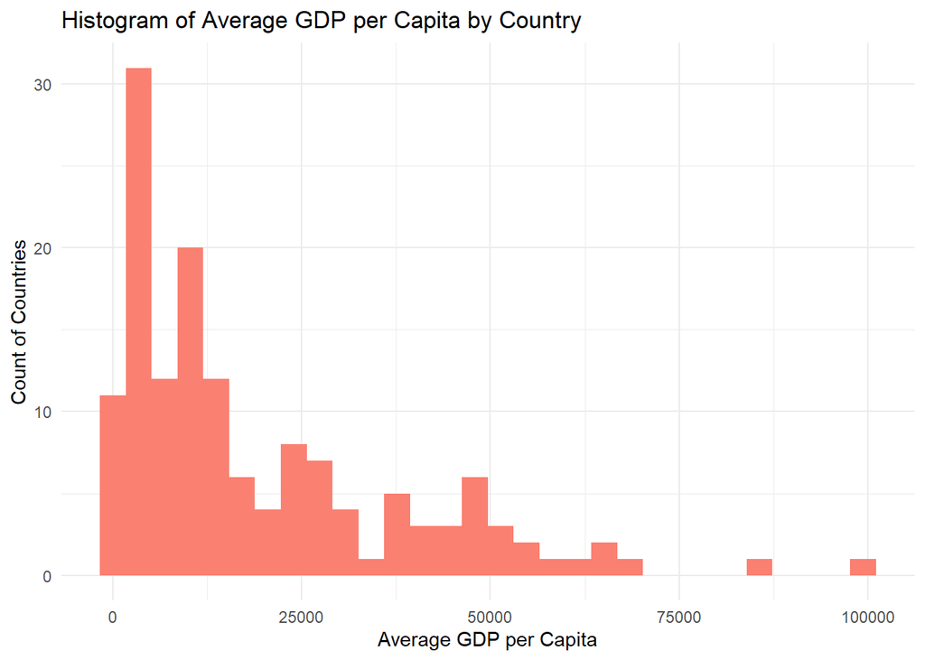

L’histogramme du GPI montre une distribution des scores moyens de l’indice de paix mondial (Global Peace Index) par pays. Il semble y avoir une concentration plus élevée de pays avec un GPI moyen autour de 2.0, ce qui pourrait suggérer une tendance vers une stabilité modérée dans l’échantillon de pays analysé. Des scores GPI plus élevés indiquent une paix moindre. Ainsi, une concentration autour de cette valeur médiane peut indiquer que de nombreux pays se situent dans une zone intermédiaire de paix/stabilité selon cet indice. La présence de pays à la fois dans les gammes inférieures et supérieures pourrait indiquer une variabilité significative en termes de paix à travers le monde.

**(GPI et PIB) vs Mortalité**

Pour mieux comprendre l’impact des conflits armés et de la situation économique sur la mortalité infantile due à la pneumonie, nous allons générer des visualisations à partir de nos données nettoyées. Ces graphiques nous aideront à savoir si les conflits et les niveaux économiques sont liés à une augmentation ou une réduction des taux de mortalité infantile.

En utilisant des méthodes de régression linéaire, nous pourrons évaluer la force et la signification de ces relations, nous fournissant une base pour une analyse statistique plus approfondie

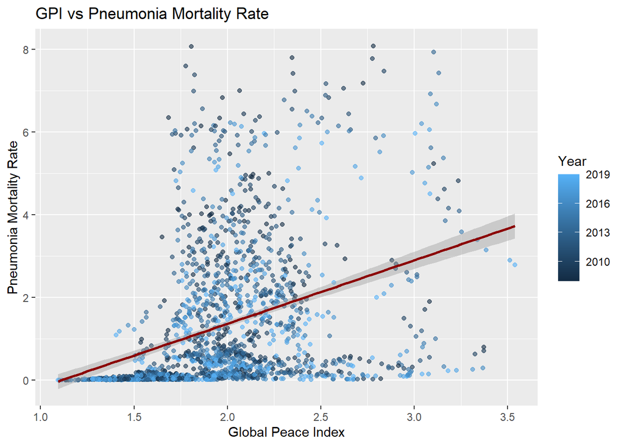

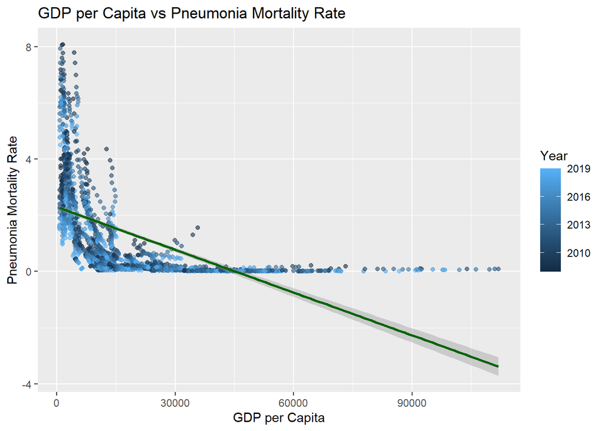

ANALYSE DE RESULTATS : L’analyse des graphiques indique une corrélation entre le GPI et le taux de mortalité infantile due à la pneumonie, ainsi qu’entre le PIB par habitant et ce même taux. Un GPI élevé, signifiant moins de paix, semble associé à un taux de mortalité plus élevé, ce qui pourrait refléter l’impact négatif des conflits sur les systèmes de santé. Inversement, un PIB par habitant plus élevé est généralement corrélé à un taux de mortalité plus bas, suggérant que de meilleures conditions économiques peuvent favoriser une meilleure santé infantile. Ces tendances sont cohérentes au fil des ans, comme illustré par la diversité des couleurs représentant les différentes années dans les nuages de points

**Visualisation de taux de mortalité par catégorie [2008-2019]**

Utilité boite à moustaches :

Les boîtes à moustaches pour chaque année de 2008 à 2019 sont très utiles pour visualiser la répartition des taux de mortalité infantile dus à la pneumonie en fonction des catégories de GPI et de PIB. Avec de multiples pays dans l’échantillon, ces graphiques permettent de distinguer rapidement où se situent la majorité des observations—la médiane—et de comprendre la variabilité ou la dispersion des données autour de cette médiane à travers les quartiles.

**Par catégorie de GPI**

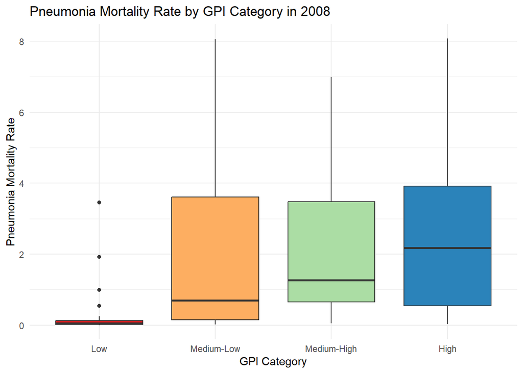

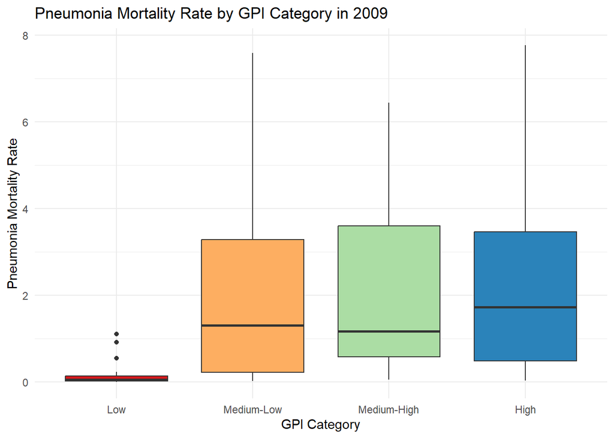

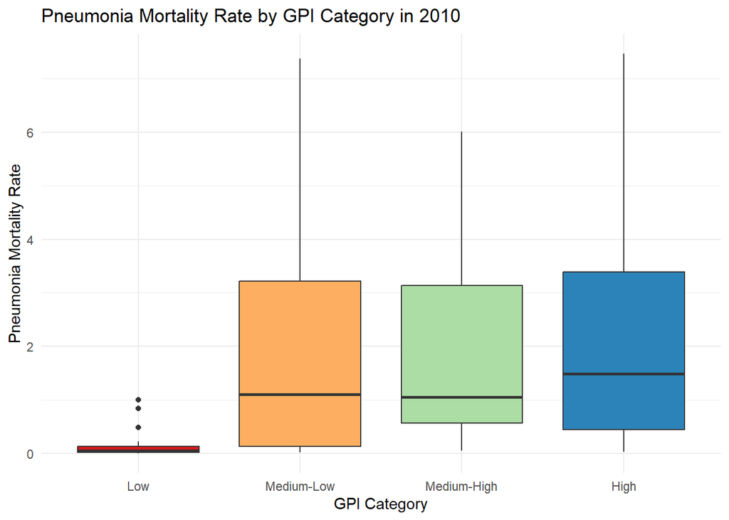

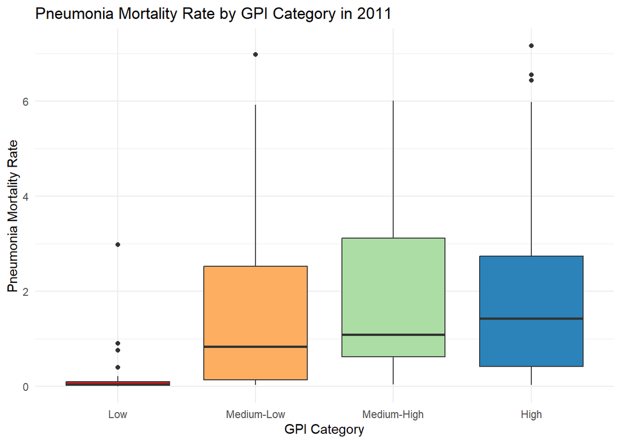

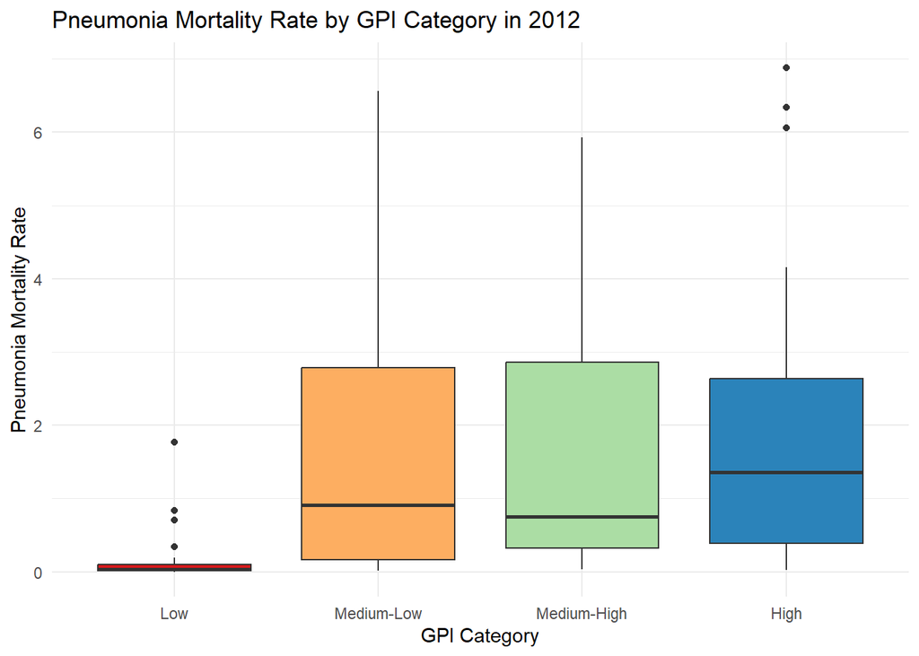

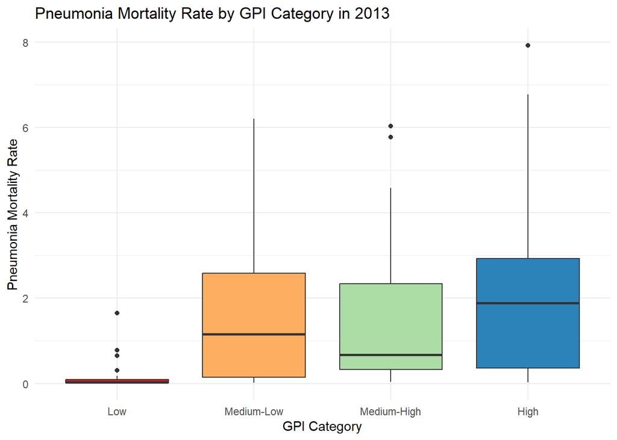

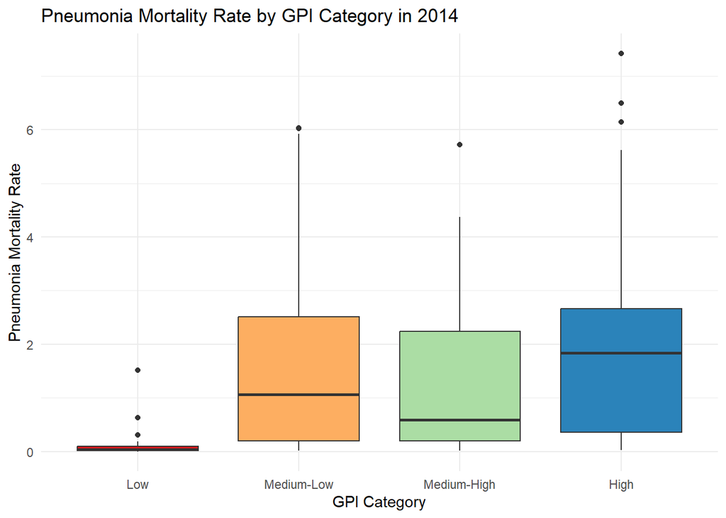

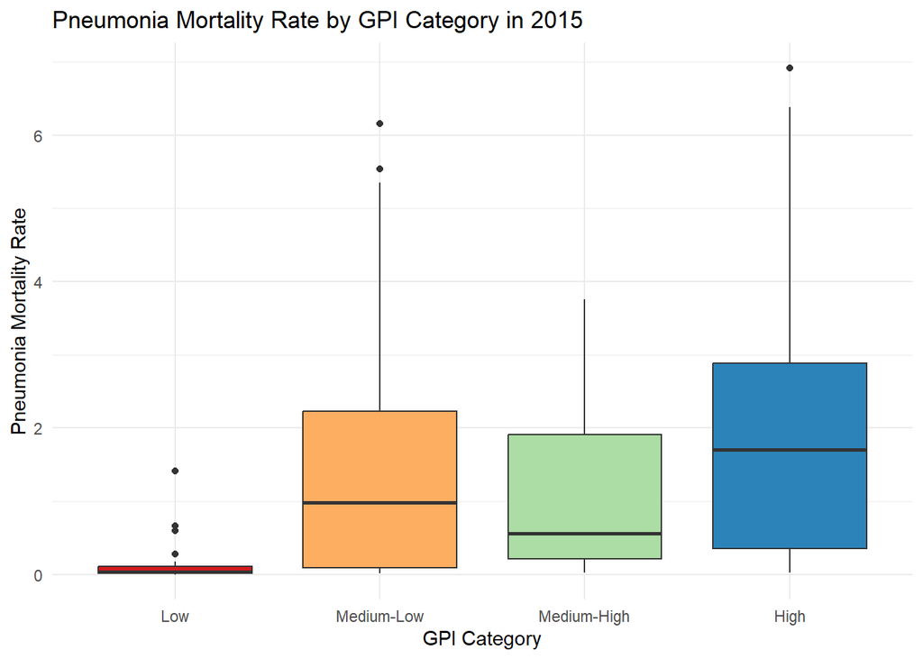

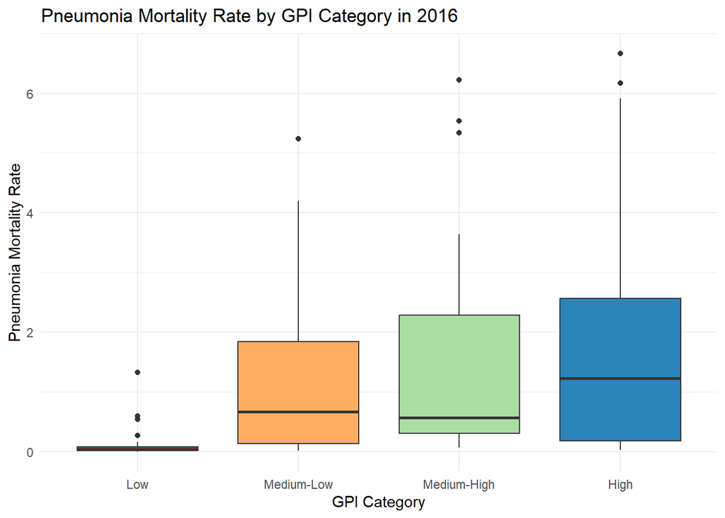

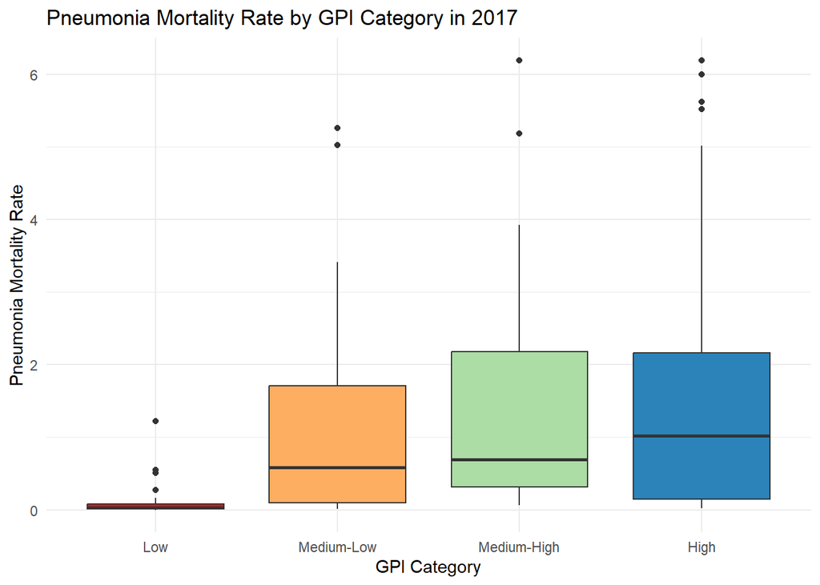

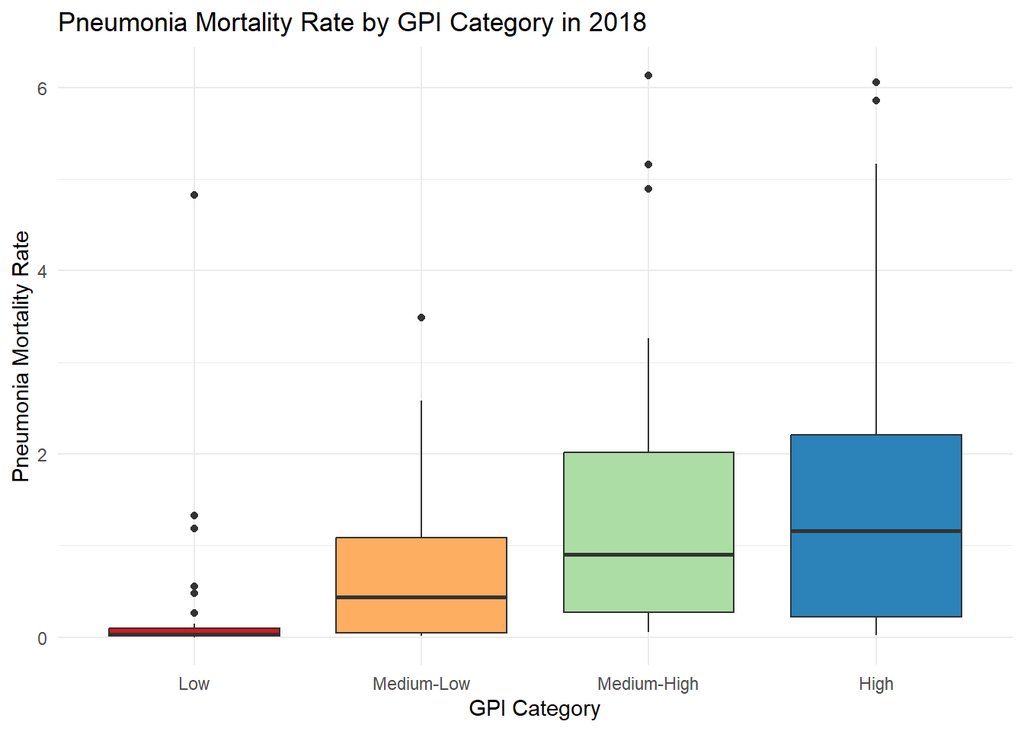

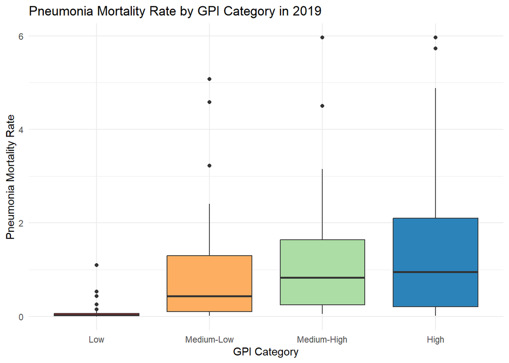

**Par catégorie de GDP**

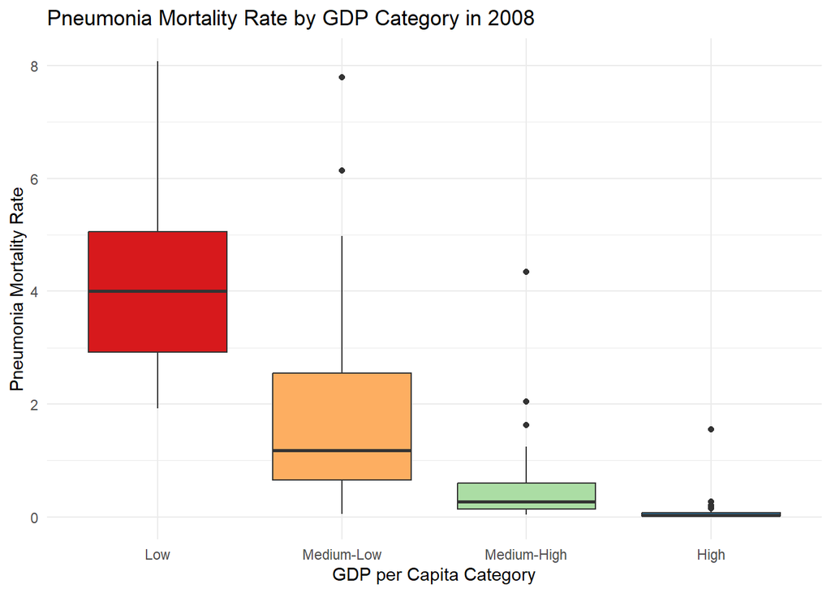

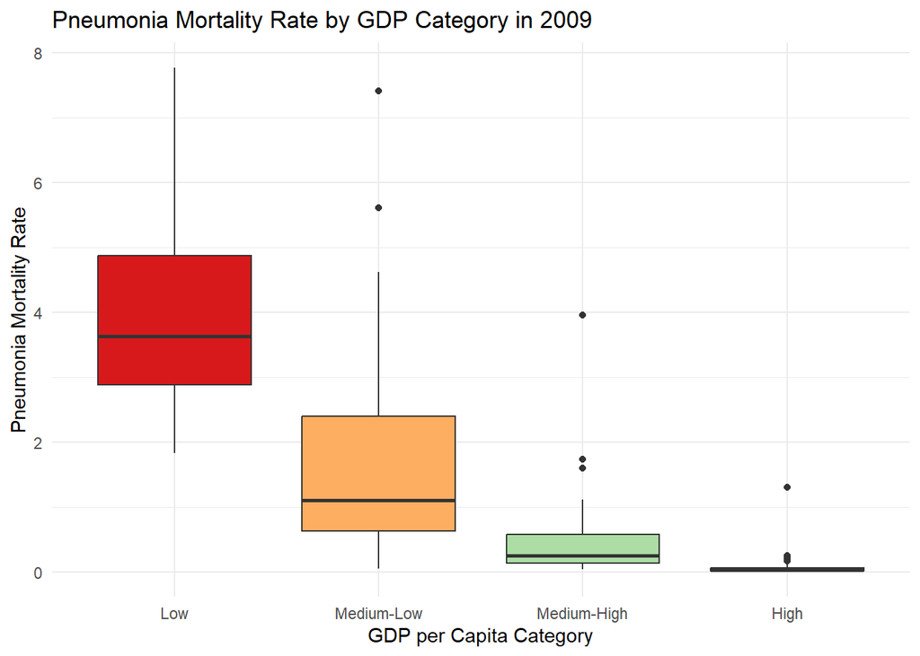

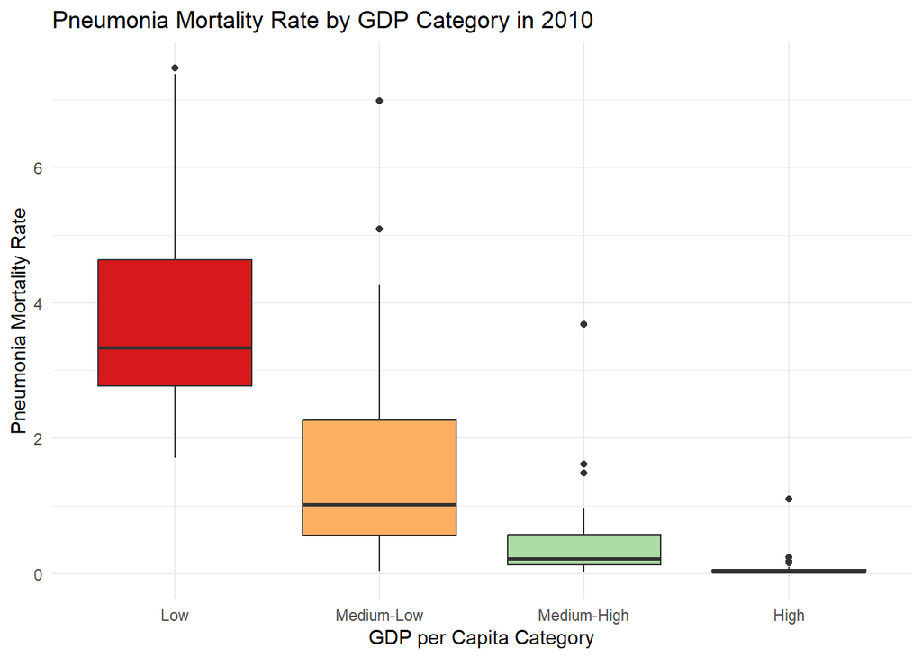

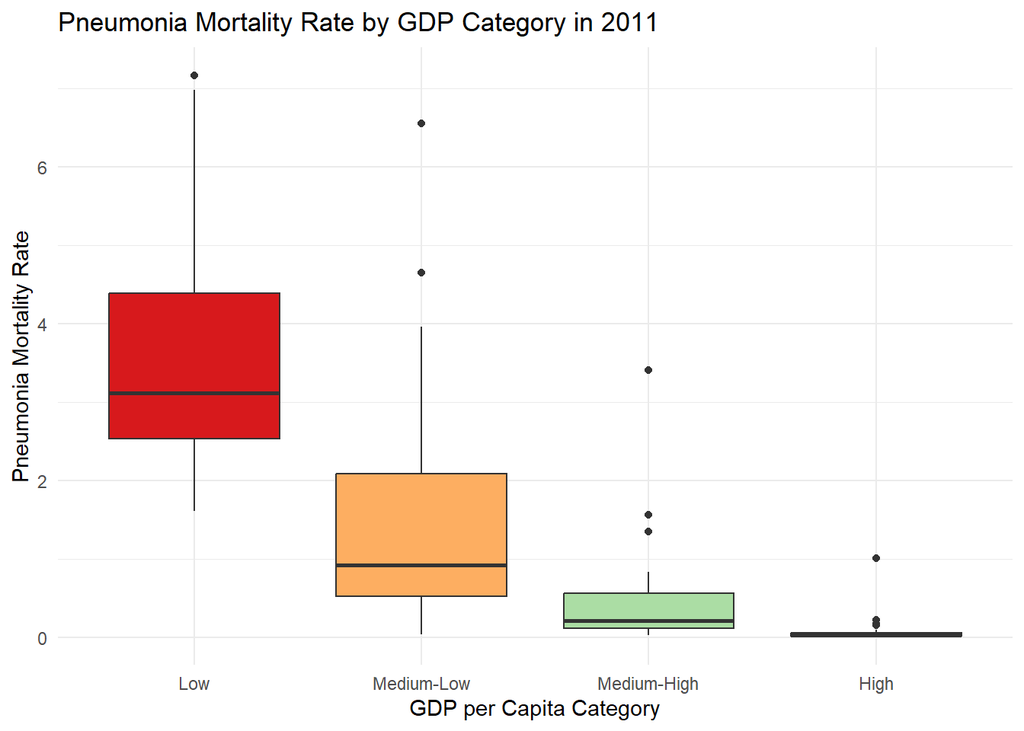

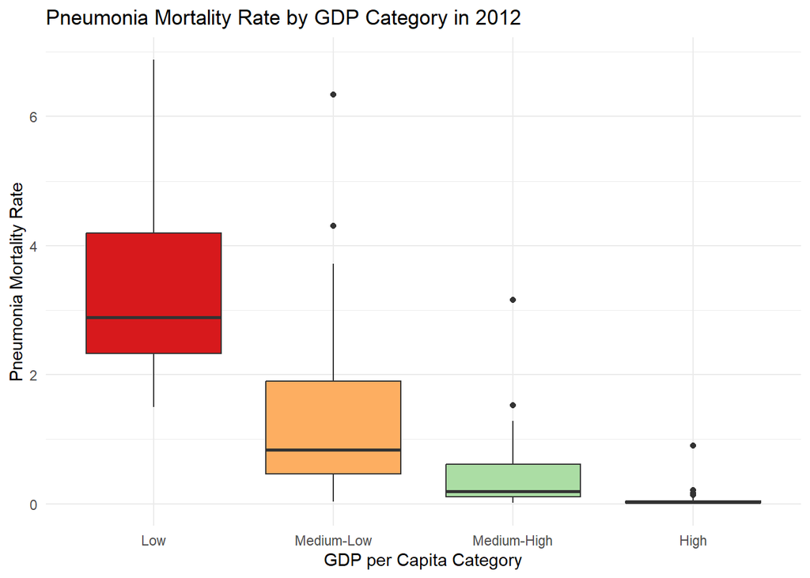

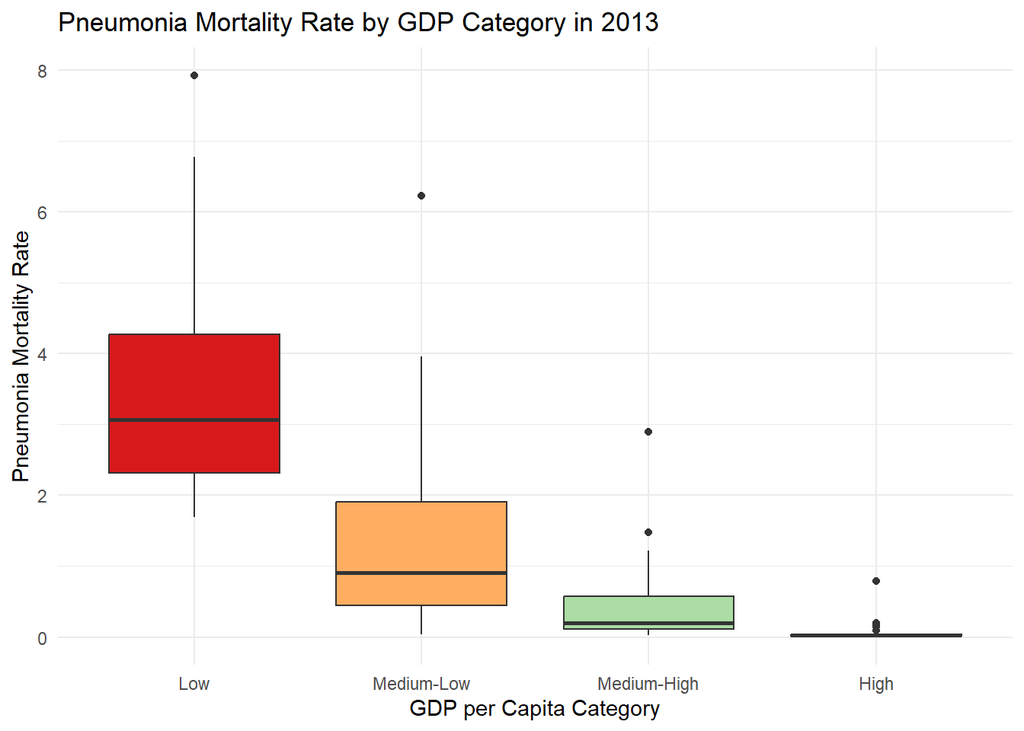

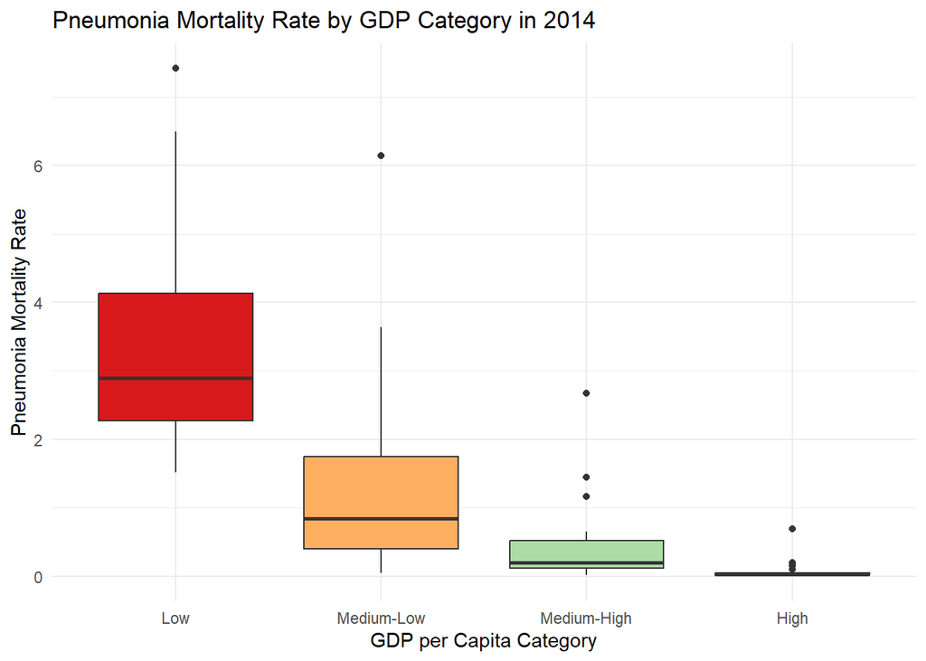

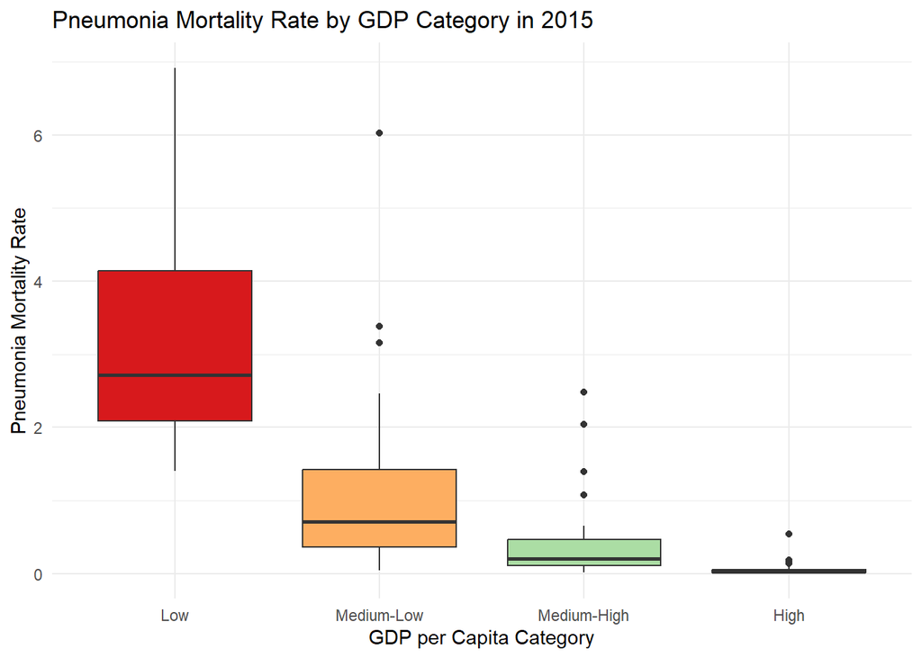

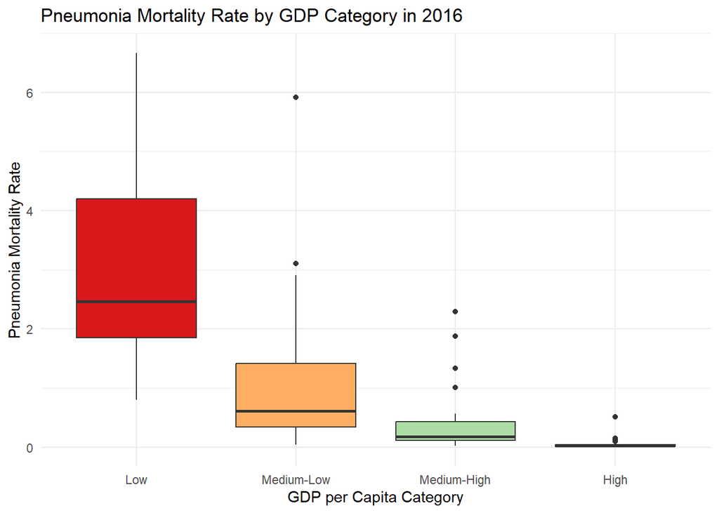

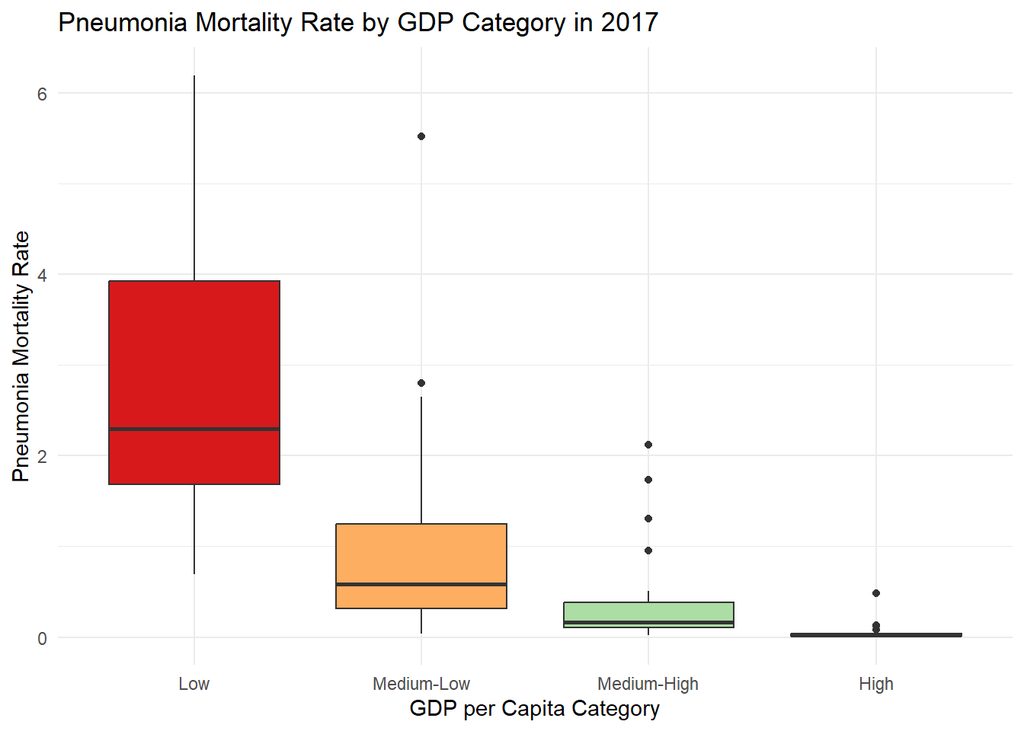

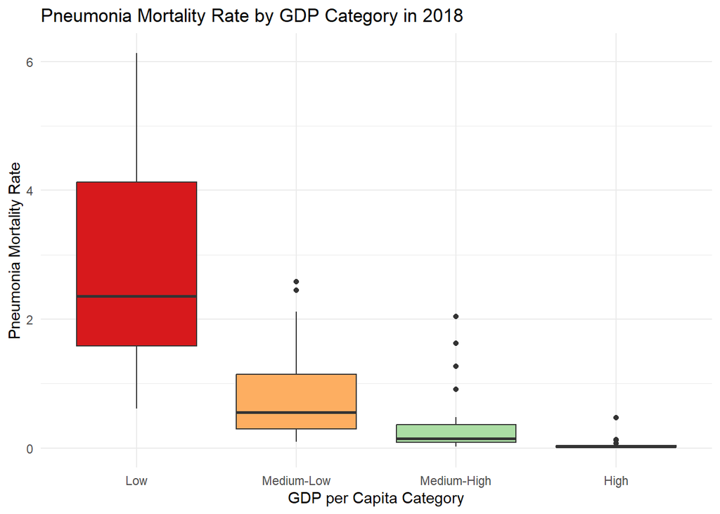

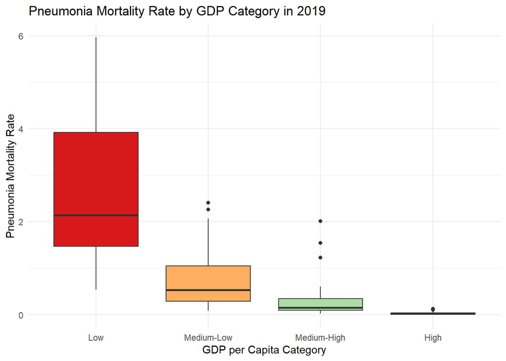

**Visualisation de l’impact des conflits sur le PIB par habitant ET l’effet combiné sur le taux de mortalité [2008-2019]**

On utilise des régressions linéaires chaque année pour mesurer comment les conflits (via le GPI) et l’économie (à travers le PIB par habitant) affectent le taux de mortalité infantile par pneumonie. En analysant année par année, nous pouvons voir de façon détaillée comment ces facteurs changent avec le temps .

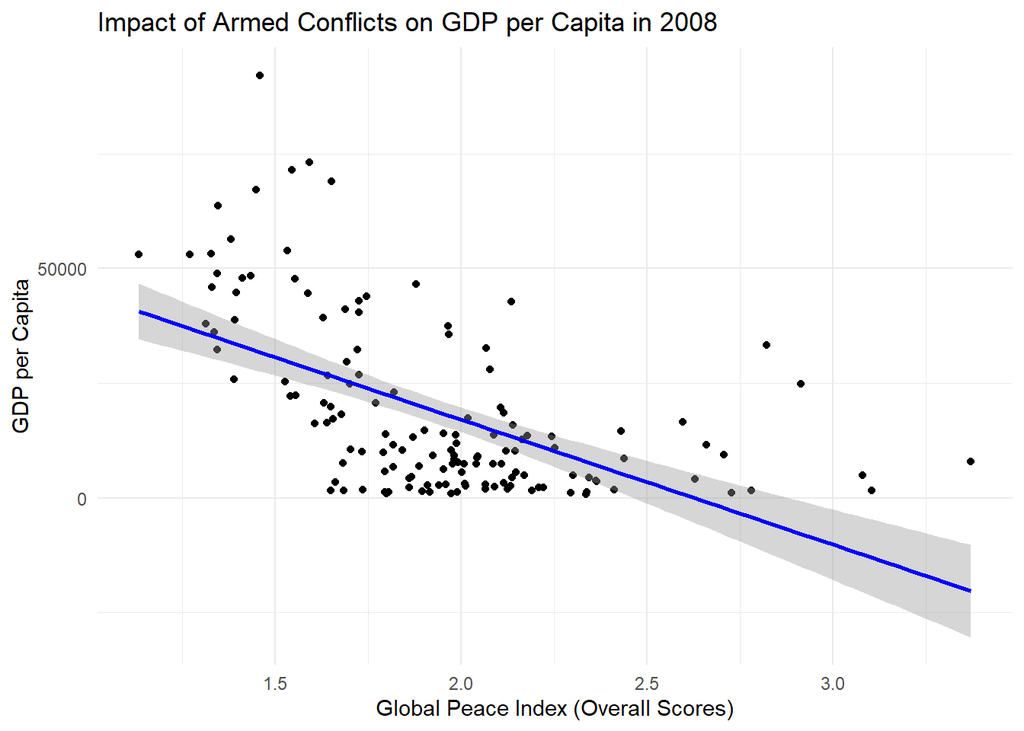

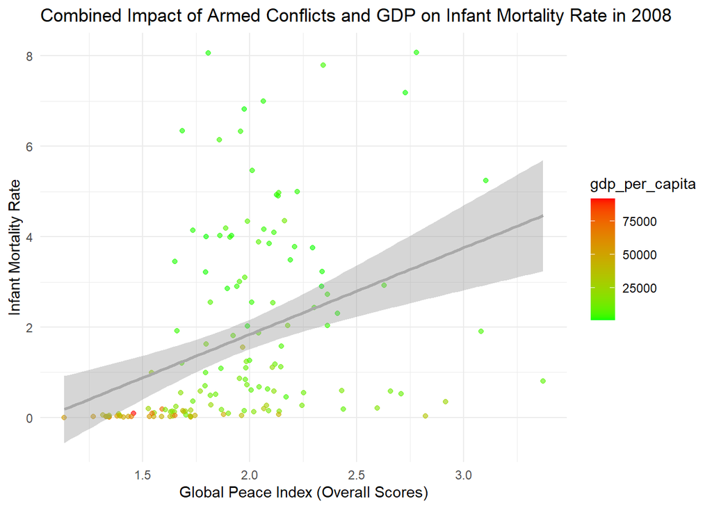

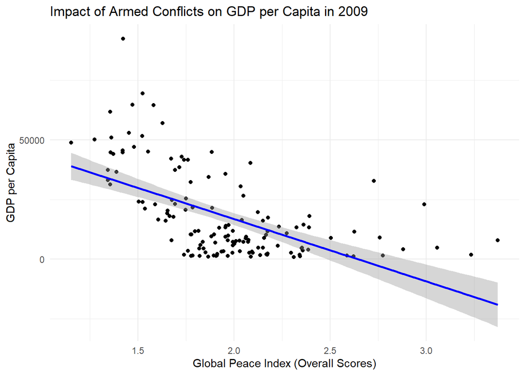

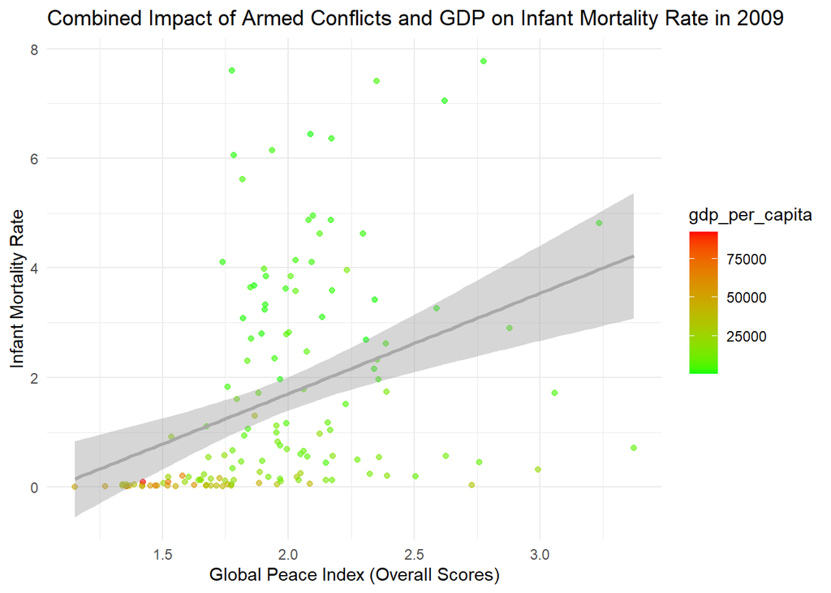